# DATA607 - Assignment 2

Michael Ippolito

2/11/2021

# OVERVIEW

| 1. The Outpost | 2. The Invisible Man | 3. The Platform (El Hoyo) |
| --- | --- | --- |
| 4. Mulan | 5. Parasite | 6. Uncut Gems |

# DATA

### Entity relationship diagram

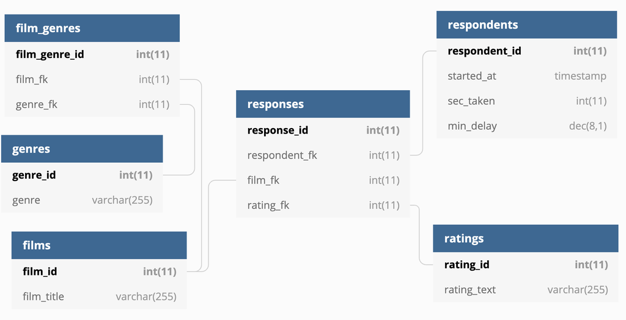

Image of an entity relationship diagram

### Films and genres

| film_id | film_title | genres |
| --- | --- | --- |
| 1 | The Outpost | drama, war |
| 2 | The Invisible Man | horror, mystery and thriller |
| 3 | The Platform (El Hoyo) | mystery and thriller, sci fi |
| 4 | Mulan | action, aventure |
| 5 | Parasite | comedy, drama, mystery and thriller |
| 6 | Uncut Gems | comedy, mystery and thriller |

### Ratings

| rating_id | rating_text |
| --- | --- |
| 0 | I didn’t see this film. |
| 1 | What’s the strongest word for hate? |
| 2 | Boo. :( |
| 3 | Meh, take it or leave it. |
| 4 | Not too shabby! |
| 5 | I love it so much! |

### Respondents

| respondent_id | started_at | sec_taken | min_delay |
| --- | --- | --- | --- |
| 1 | 2021-02-09 22:22:43 | 38 | 1.7 |
| 2 | 2021-02-09 22:22:41 | 102 | 1.7 |
| 3 | 2021-02-09 22:54:24 | 89 | 33.4 |
| 4 | 2021-02-09 23:13:28 | 359 | 52.5 |
| 5 | 2021-02-10 00:07:17 | 38 | 106.3 |

### Survey responses

| response_id | respondent_fk | film_fk | film_title | rating_fk | rating_text |
| --- | --- | --- | --- | --- | --- |
| 1 | 1 | 1 | The Outpost | NA | NA |
| 2 | 1 | 2 | The Invisible Man | NA | NA |
| 3 | 1 | 3 | The Platform (El Hoyo) | NA | NA |
| 4 | 1 | 4 | Mulan | NA | NA |
| 5 | 1 | 5 | Parasite | 5 | I love it so much! |
| 6 | 1 | 6 | Uncut Gems | NA | NA |
| 7 | 2 | 1 | The Outpost | NA | NA |
| 8 | 2 | 2 | The Invisible Man | 4 | Not too shabby! |
| 9 | 2 | 3 | The Platform (El Hoyo) | NA | NA |
| 10 | 2 | 4 | Mulan | 4 | Not too shabby! |

# SURVEY RESULTS

As the evidence indicates, obviously I need to find some new friends. Many of my so-called friends and family didn’t even see some of the best movies on the list.

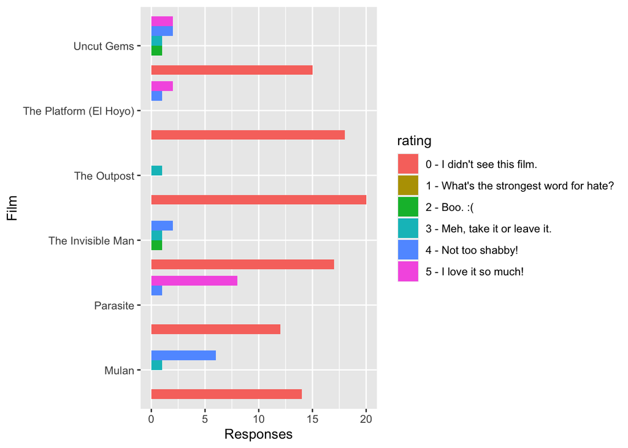

### *Parasite* is the Clear Winner

Excluding results where respondents indicated they hadn’t seen the film, the winner is obvious.

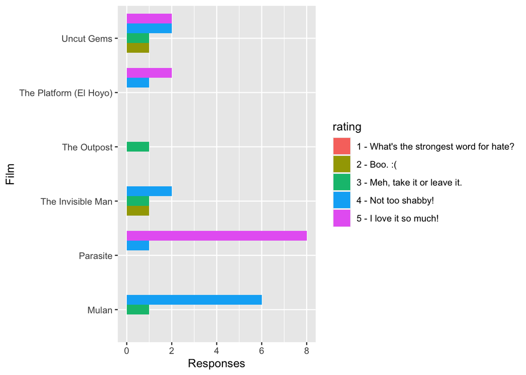

### People Love Drama, a Good Laugh–and a Good Surprise

#### (but only if it’s not too scary)

Broken out by genre, the survey respondents favoured films having elements of mystery, drama, and comedy. The biggest losers were the war, science fiction, and horror films.

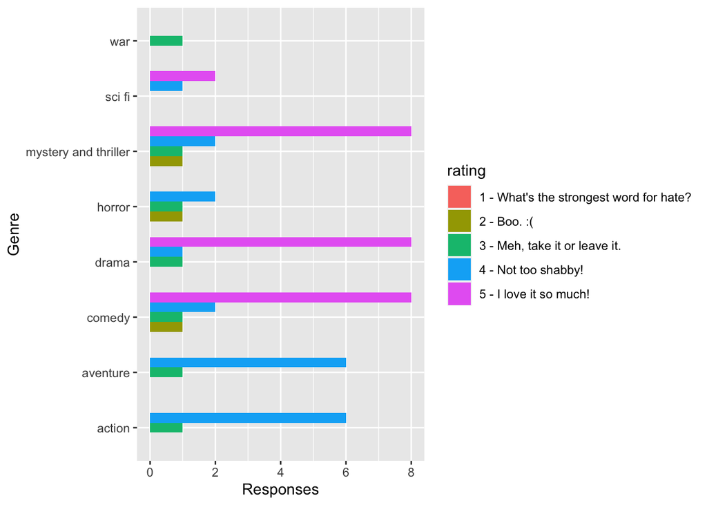

# FILM RECOMMENDATIONS

I generated a list of recommendations for each respondent based on which films they rated either a 4 or 5. If they didn’t see any of the movies, or if they’ve already seen all the movies in the list for their favourite genres, I picked one for them but marked it with a disclaimer.

| respondent_id | film_title | disclaimer |
| --- | --- | --- |
| 1 | The Platform (El Hoyo) |  |
| 2 | Uncut Gems |  |
| 3 | The Outpost |  |
| 4 | The Invisible Man |  |
| 5 | Mulan | (You might be disappointed) |
| 6 | The Platform (El Hoyo) |  |
| 7 | The Outpost | (You might be disappointed) |
| 8 | Uncut Gems | (You might be disappointed) |
| 9 | The Outpost | (You might be disappointed) |
| 10 | Mulan | (You might be disappointed) |
| 11 | The Outpost | (You might be disappointed) |
| 12 | The Invisible Man | (You might be disappointed) |
| 13 | The Invisible Man |  |
| 14 | The Invisible Man |  |
| 15 | The Platform (El Hoyo) |  |
| 16 | Uncut Gems | (You might be disappointed) |
| 17 | The Platform (El Hoyo) | (You might be disappointed) |
| 18 | The Platform (El Hoyo) |  |
| 19 | Uncut Gems | (You might be disappointed) |
| 20 | Uncut Gems | (You might be disappointed) |
| 21 | Uncut Gems | (You might be disappointed) |

# FURTHER INVESTIGATION

### Can we correlate people’s film preferences to any of the following?

- **Morning people vs night people**: (the time of day when they took the survey)
- **Pantsers vs planners** (how long spent taking the survey)
- **Procrastinators vs anticipators** (how long they waited before they took the survey)

### MORNING PEOPLE VS NIGHT PEOPLE

I would have expected night people to be less serious and, hence, to favour comedies. Instead, there doesn’t seem to be much of a difference.

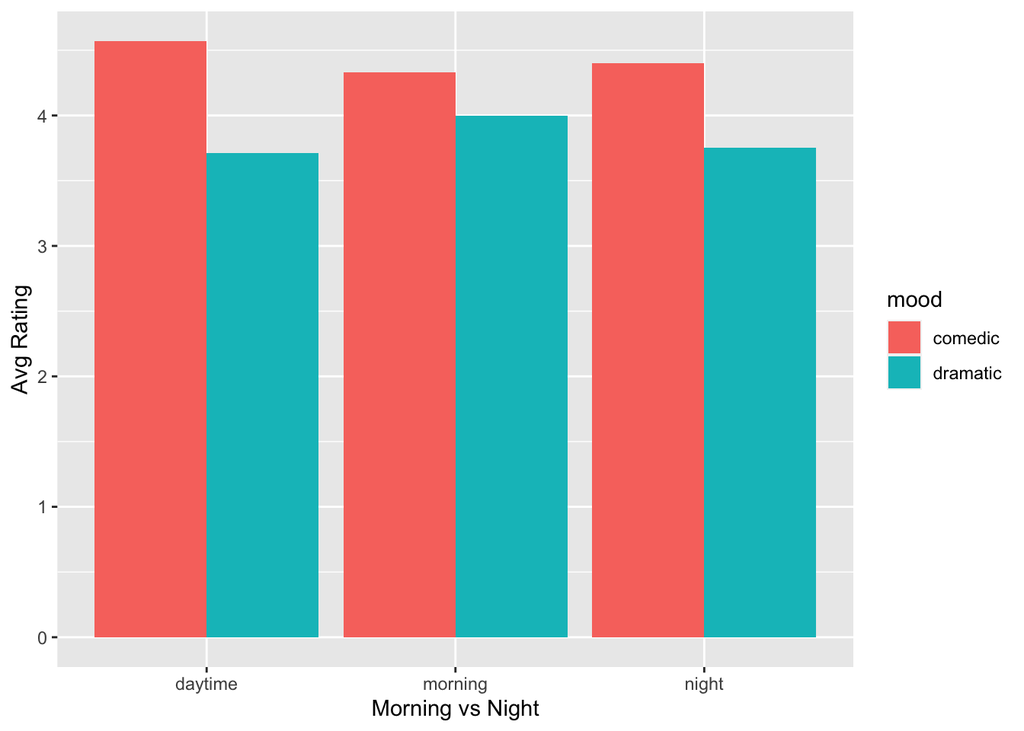

### PANTSERS VS PLANNERS

I was surprised here again. My expectation was that “pantsers” would prefer comedies. But the distribution was fairly even.

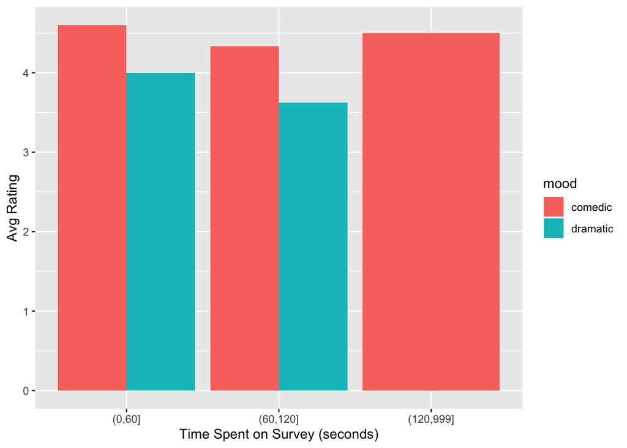

### PROCRASTINATORS VS ANTICIPATORS

Another disappointing conclusion: I thought procrastinators would like comedies more. Again, the spread looks pretty even to me.

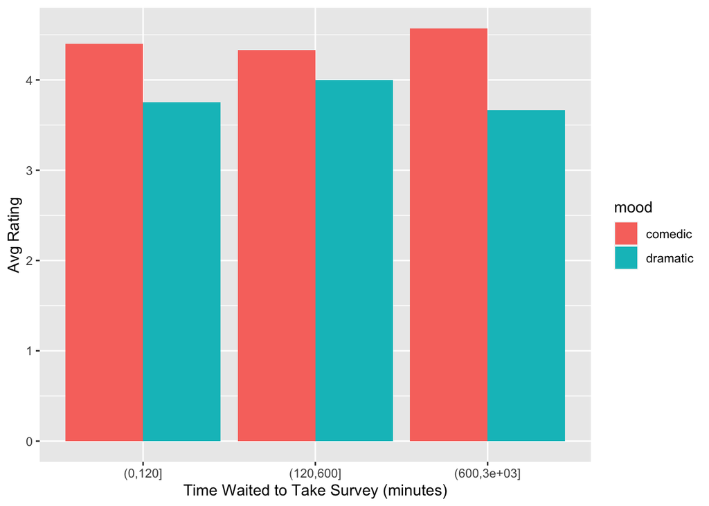

### FOILED AGAIN!

Creating a sort of wonky Briggs-Meyer classification system, I tried finding a correlation between genre and the combination of the above attributes. No such luck.

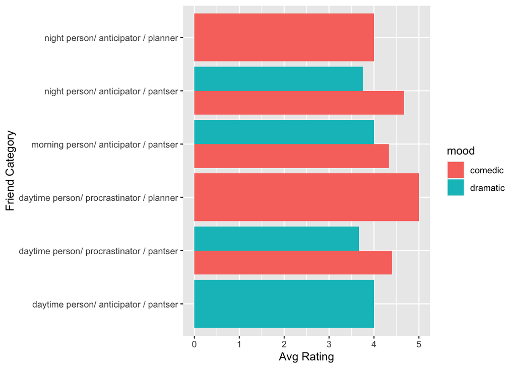

### A LAST-DITCH EFFORT TO FIND SOME KIND OF MEANING IN ALL OF THIS

I wanted to find some correlation in my data to make it worth writing these ~250 lines of code. What I found is that I only know two people who share my taste in films. Depressingly, this confirms my earlier conjecture that I need to find new friends.

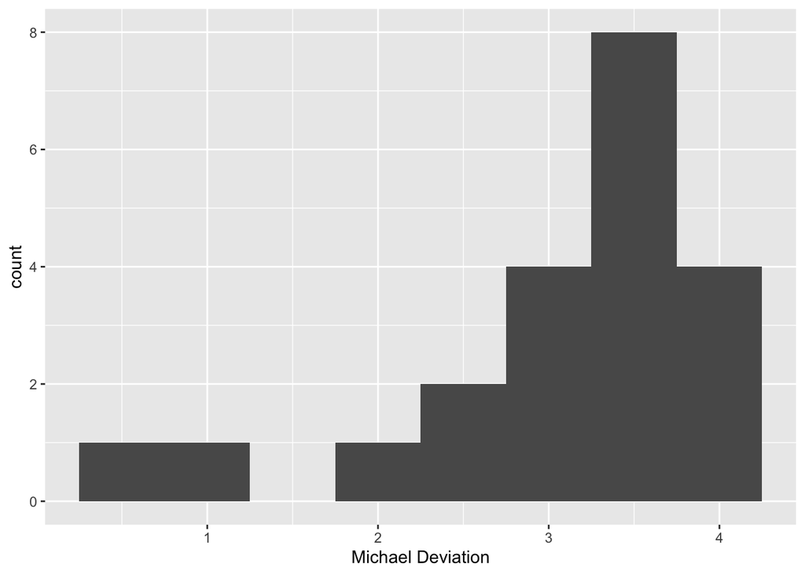